# Исследование структуры временных рядов в R (альтернативная версия)

### Преобразование Бокса-Кокса

Помимо логарифмирования, можно применять и другие преобразования ряда, чтобы уменьшить зависимость амплитуды колебаний от уровня ряда. Например, применяются **степенные преобразования** (**power transformations**):

$$w_t = y_t ^ {p},$$

где
$$p \in \{\frac{1}{2}, \frac{1}{3}, -1 \}.$$

Бокс и Кокс предложили удобный способ описания целого семейства преобразований, включающего степенные преобразования и логарифмирование с помощью параметра $\lambda$.

**Преобразование Бокса-Кокса** (**Box-Cox transformation**) задается следующим образом:

$$w_t =
\begin{cases}
\log{y} & \text{при } \lambda = 0 \\
(y_t^\lambda - 1) / \lambda & \text{иначе.}
\end{cases}$$

Логарфм используется натуральный.

Для преобразования временных рядов в R имеется функция `forecast::BoxCox()`.

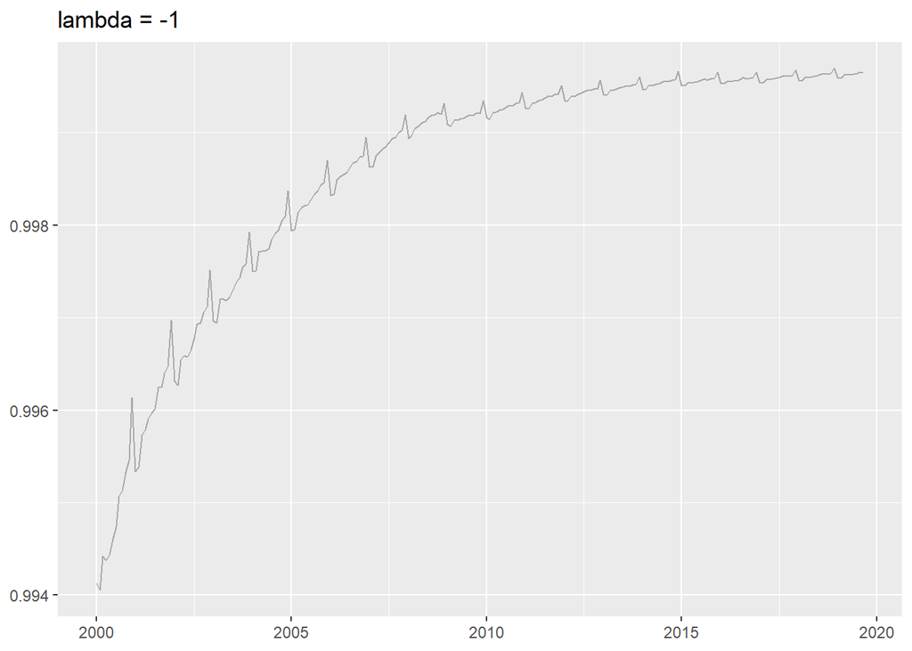

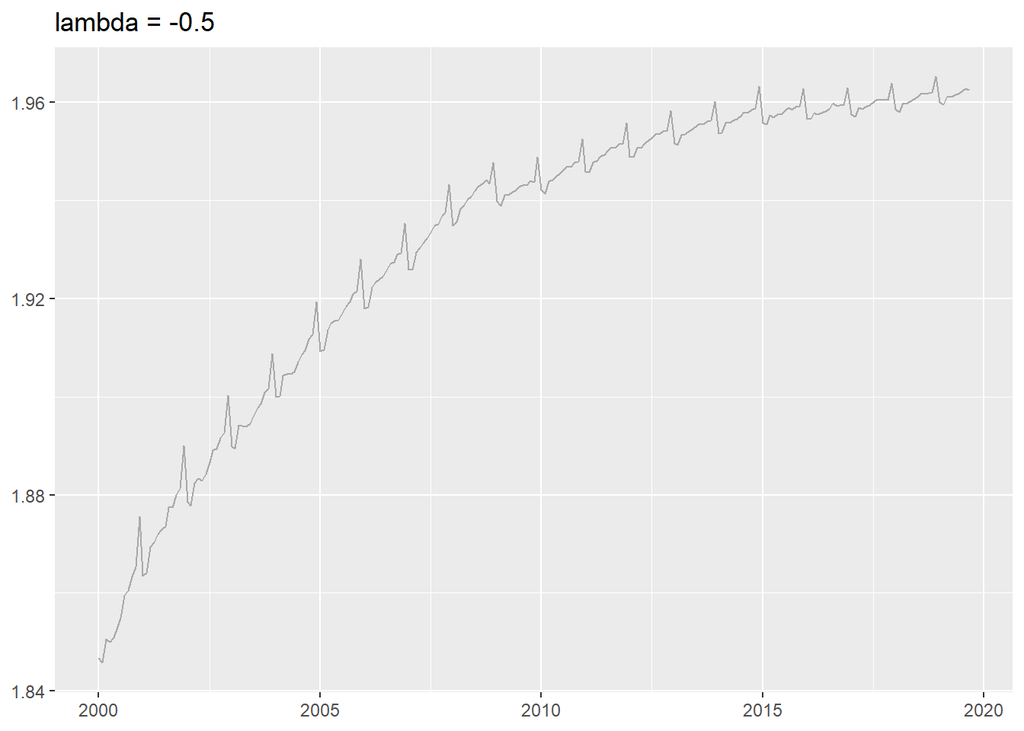

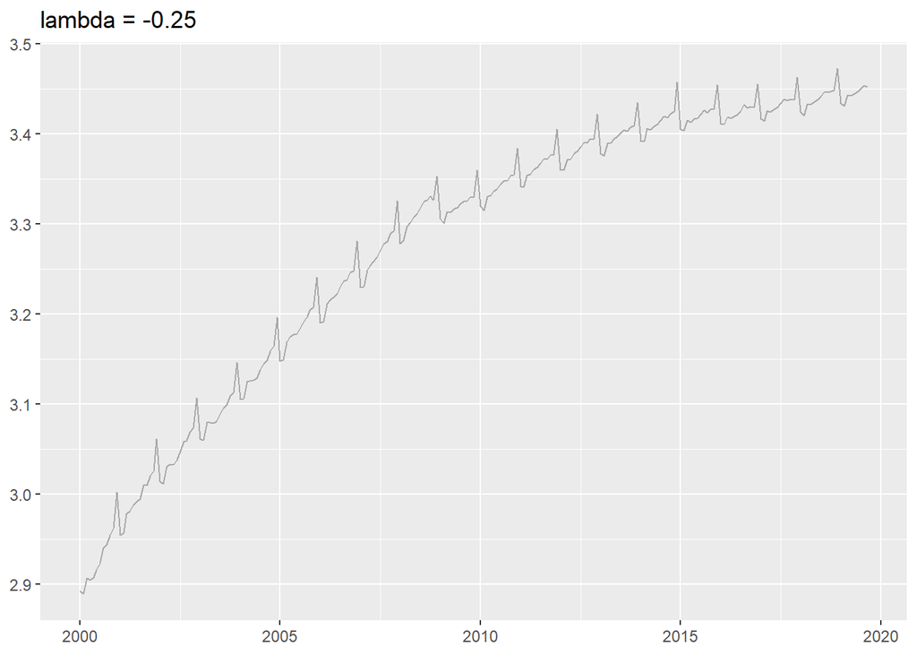

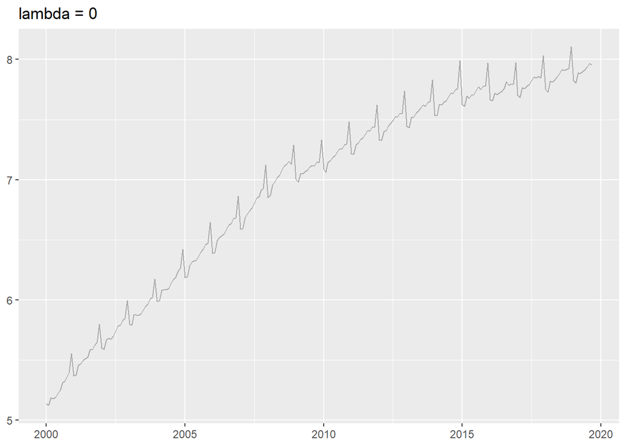

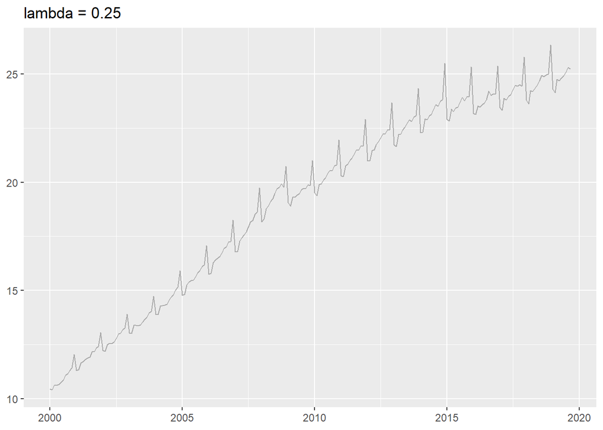

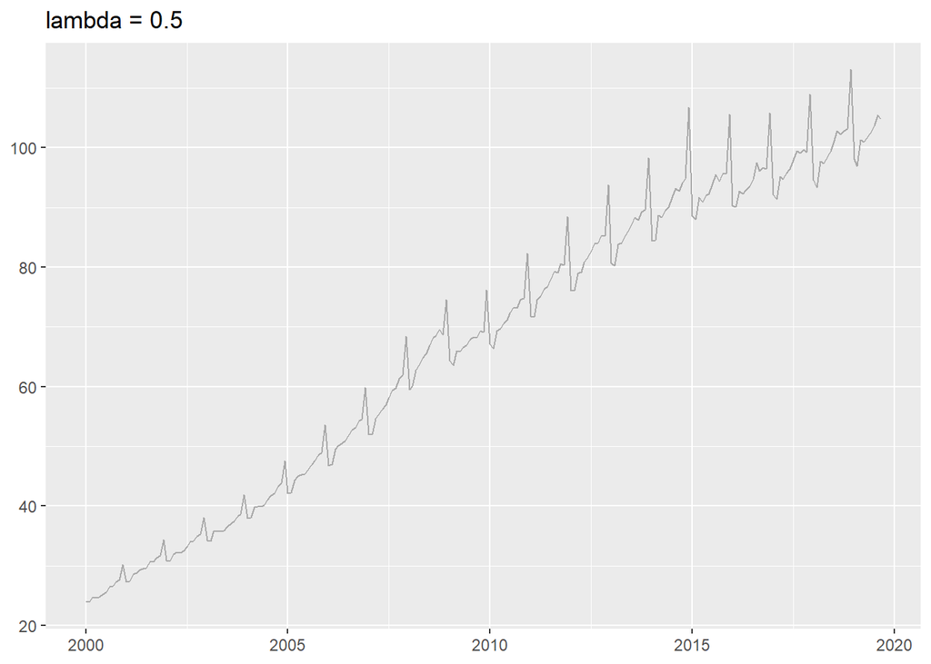

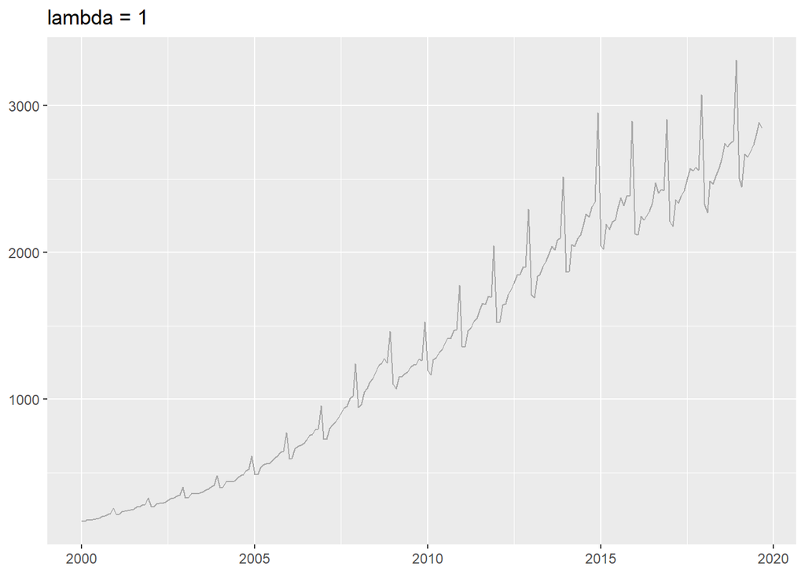

```r
# Параметр преобразования изменяется в цикле
for (lambda in c(-1, -0.5, -0.25, 0, 0.25, 0.5, 1)) {
  p <- autoplot(BoxCox(retail_ts, lambda)) +
    labs(title = str_c('lambda = ', lambda),
         x = NULL, y = NULL) +
    geom_line(color = 'darkgray')
  print(p)

}
```

Аналогичный пример, демонстрирующий влияние параметра $\lambda$, можно посмотреть [здесь](https://otexts.com/fpp2/transformations.html)

Для автоматического подбора $\lambda$, при котором преобразованный ряд наиболее близок к аддитивной сезонной модели, можно использовать функцию `forecast::BoxCox.lambda()`. О применяемых методах подбора параметра $\lambda$ можно прочитать в справке.

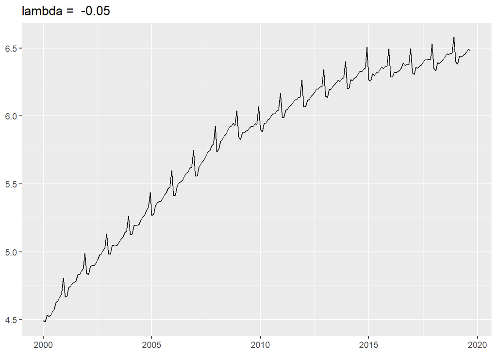

```r
best_lambda <- BoxCox.lambda(retail_ts)

autoplot(BoxCox(retail_ts, best_lambda)) +
    labs(title = paste('lambda = ', round(best_lambda, 2)),
         x = NULL, y = NULL)
```

Полученное в результате подбора значение параметра можно использовать в качестве ориентира, поскольку дробные значения $\lambda$ затрудняют интерпретацию данных. Например, $\lambda = 0.42$ лучше заменить на $\lambda = 0.5$ (квадратный корень).

В данном случае значение параметра $\lambda$ близко к нулю, следовательно для преобразования лучше всего применять логарифмирование.

Чтобы перейти от преобразованных данных назад к исходным, необходимо применить обратное преобразование (**back-transform**). Математически **обратное преобразование Бокса-Кокса** (**reverse Box-Cox transformation**) задается следующим образом:

$$y_t =
\begin{cases}
\exp(w_t) & \text{при } \lambda = 0 \\
(\lambda w_t + 1) ^ \frac{1}{\lambda} & \text{иначе.}
\end{cases}$$

В R для обратного преобразования Бокса-Кокса используется функция `forecast::InvBoxCox()`.

При использовании преобразований Бокса-Кокса помните о следующих его особенностях:

- При наличии во временном ряде отрицательных или нулевых значений преобразование невозможно. Однако можно прибавить константу ко всем значения ряда, чтобы исключить отрицательные значения.
- Выбирайте легко интерпретируемые значения $\lambda$ (0.37 -> 0.33, или кубический корень).
- Методы прогнозирования слабо чувствительны к изменению параметра $\lambda$
- Часто преобразование не требуется
- Преобразование иногда практически не изменяет точечный прогноз, но сильно влияет на доверительные интервалы для прогноза.

## Дефляция

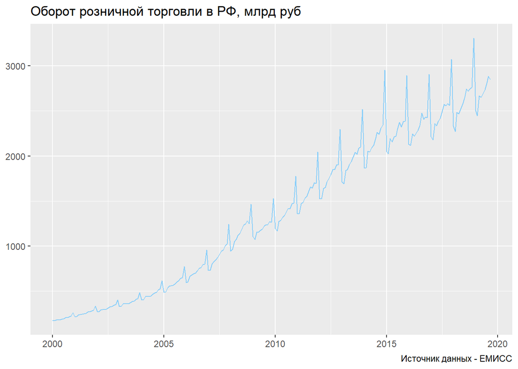

```r
autoplot(retail_ts) +
  labs(title = retail_title, caption = retail_source, x = NULL, y = NULL) +
  geom_line(color = 'lightSkyblue')
```

# Индекс-дефлятор

Чтобы исключить эффект инфляции при анализе временных рядов применяется корректировка данных ряда, основанная на использовании индекса-дефлятора. В качестве такого индекса можно использовать индекс потребительских цен, который агрегированно отражает рост цен на потребительские товары.

В этом примере мы используем индекс потребительских цен, загруженный с сайта Росстата. Исходные данные находятся в файле data/gks_cpi.xlsx

Загрузим эти данные.

```r
cpi_raw <- read_excel('data/gks_cpi.xlsx', skip = 2)

cpi_raw %>% head
```

```
## # A tibble: 6 x 13
##   `Все товары и у~ январь февраль  март апрель   май  июнь  июль август
##              <dbl>  <dbl>   <dbl> <dbl>  <dbl> <dbl> <dbl> <dbl>  <dbl>
## 1             2002   103.    101.  101.   101.  102.  101.  101.  100.
## 2             2003   102.    102.  101.   101.  101.  101.  101.   99.6
## 3             2004   102.    101.  101.   101.  101.  101.  101.  100.
## 4             2005   103.    101.  101.   101.  101.  101.  100.   99.9
## 5             2006   102.    102.  101.   100.  100.  100.  101.  100.
## 6             2007   102.    101.  101.   101.  101.  101.  101.  100.
## # ... with 4 more variables: сентябрь <dbl>, октябрь <dbl>, ноябрь <dbl>,
## #   декабрь <dbl>
```

Исправим имя первого столбца

```r
names(cpi_raw)[1] <- 'year'
```

Данные представляют собой сводную 2D-таблицу, которую надо привести к длинному формату. Также для удобства необходимо создать поле с датой.

```r
cpi_tbl <-
  cpi_raw %>%
  gather(key = 'month', value = 'cpi', -1) %>%
  mutate(date = ymd(paste(year, month, 1))) %>%
  select(date, cpi) %>%
  arrange(date)

cpi_tbl %>% head()
```

```
## # A tibble: 6 x 2
##   date         cpi
##   <date>     <dbl>
## 1 2002-01-01  103.
## 2 2002-02-01  101.
## 3 2002-03-01  101.
## 4 2002-04-01  101.
## 5 2002-05-01  102.
## 6 2002-06-01  101.
```

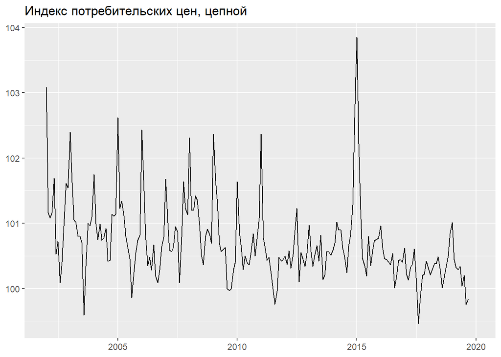

```r
cpi_tbl %>%
  ggplot(aes(date, cpi)) +
  geom_line() +
  labs(title = 'Индекс потребительских цен, цепной', x = NULL, y = NULL)
```

Индекс потребительских цен в базе - цепной, т.е. его значения - это процентное изменение по сравнению с предыдущим периодом. В таком виде данные использовать неудобно, требуется пересчитать значения индекса к некоторому базовому периоду.

Примем за базисный период январь 2002 года - начало данных по индексу потребительских цен. Для остальных периодов базисный индекс будет равен прозведению с нарастающим итогом цепных индексов текущего и всех предыдущих периодов.

```r
cpi_tbl[1, 'cpi'] = 100

cpi_tbl <-
  cpi_tbl %>%
  mutate(cpi_base = cumprod(cpi/100))

cpi_tbl %>% head()
```

```
## # A tibble: 6 x 3
##   date         cpi cpi_base
##   <date>     <dbl>    <dbl>
## 1 2002-01-01  100      1
## 2 2002-02-01  101.     1.01
## 3 2002-03-01  101.     1.02
## 4 2002-04-01  101.     1.03
## 5 2002-05-01  102.     1.05
## 6 2002-06-01  101.     1.06
```

Создадим временной ряд `ts` для индекса потребительских цен:

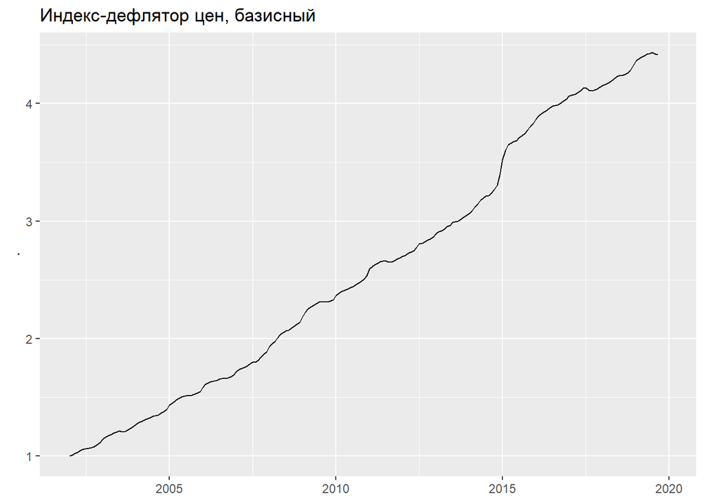

```r
cpi_ts <-
  cpi_tbl$cpi_base %>%
  ts(start = c(2002, 1), frequency = 12)


cpi_ts %>%
  autoplot() +
  labs(x = NULL,
       title = 'Индекс-дефлятор цен, базисный')
```